# PracticalML

Chengyu Hang

2021/1/4

## Overview

Using devices such as Jawbone Up, Nike FuelBand, and Fitbit it is now possible to collect a large amount of data about personal activity relatively inexpensively. These type of devices are part of the quantified self movement – a group of enthusiasts who take measurements about themselves regularly to improve their health, to find patterns in their behavior, or because they are tech geeks. One thing that people regularly do is quantify how much of a particular activity they do, but they rarely quantify how well they do it. In this project, your goal will be to use data from accelerometers on the belt, forearm, arm, and dumbell of 6 participants. They were asked to perform barbell lifts correctly and incorrectly in 5 different ways.

## Data Loading and Processing

```r
library(caret)
library(rpart)
```

```r
library(rpart.plot)
library(RColorBrewer)
library(rattle)
library(randomForest)
library(corrplot)
library(gbm)
# set the URL for the download
UrlTrain <- "http://d396qusza40orc.cloudfront.net/predmachlearn/pml-training.csv"
UrlTest  <- "http://d396qusza40orc.cloudfront.net/predmachlearn/pml-testing.csv"

# download the datasets
training <- read.csv(url(UrlTrain))
testing  <- read.csv(url(UrlTest))

# create a partition with the training dataset
inTrain  <- createDataPartition(training$classe, p=0.75, list=FALSE)
TrainSet <- training[inTrain, ]
TestSet  <- training[-inTrain, ]

# remove variables with Nearly Zero Variance
NZV <- nearZeroVar(TrainSet)
TrainSet <- TrainSet[, -NZV]
TestSet  <- TestSet[, -NZV]

# remove variables that are mostly NA
AllNA    <- sapply(TrainSet, function(x) mean(is.na(x))) > 0.95
TrainSet <- TrainSet[, AllNA==FALSE]
TestSet  <- TestSet[, AllNA==FALSE]

# remove identification only variables (columns 1 to 5)
TrainSet <- TrainSet[, -(1:5)]
TestSet  <- TestSet[, -(1:5)]
dim(TrainSet)
```

```
## [1] 14718    54
```

```r
dim(TestSet)
```

```
## [1] 4904   54
```

With the cleaning process above, the number of variables for the analysis has been reduced to 54.

## Correlation Analysis

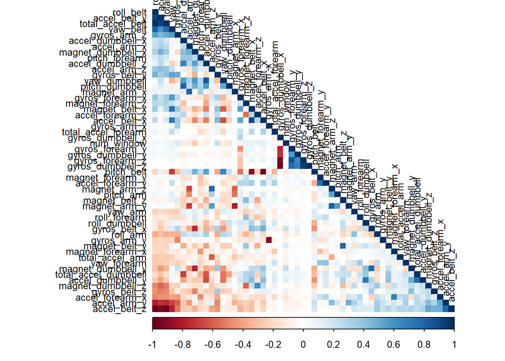

```r
corMatrix <- cor(TrainSet[, -54])
corrplot(corMatrix, order = "FPC", method = "color", type = "lower",
         tl.cex = 0.8, tl.col = rgb(0, 0, 0))
```

The highly correlated variables are shown in dark colors in the graph above.

## Prediction Model

Three methods will be applied to model the regressions (in the Train dataset) and the best one (with higher accuracy when applied to the Test dataset) will be used for the quiz predictions. The methods are: Random Forests, Decision Tree and Generalized Boosted Model, as described below. A Confusion Matrix is plotted at the end of each analysis to better visualize the accuracy of the models.

# Random Forest

```r
# model fit
set.seed(12345)
controlRF <- trainControl(method="cv", number=4, verboseIter=FALSE)
modFitRandForest <- train(classe ~ ., data=TrainSet, method="rf",
                          trControl=controlRF)
modFitRandForest$finalModel
```

```
##
## Call:
##  randomForest(x = x, y = y, mtry = param$mtry)
##                Type of random forest: classification
##                      Number of trees: 500
## No. of variables tried at each split: 27
##
##         OOB estimate of  error rate: 0.18%
## Confusion matrix:
##      A    B    C    D    E  class.error
## A 4184    0    0    0    1 0.0002389486
## B    6 2841    1    0    0 0.0024578652
## C    0    7 2560    0    0 0.0027269186
## D    0    0    6 2405    1 0.0029021559
## E    0    0    0    5 2701 0.0018477458
```

```r
# prediction on Test dataset
predictRandForest <- predict(modFitRandForest, newdata=TestSet)
confMatRandForest <- confusionMatrix(predictRandForest, as.factor(TestSet$classe))
confMatRandForest
```

```
## Confusion Matrix and Statistics
##
##           Reference
## Prediction    A    B    C    D    E
##          A 1394    1    0    0    0
##          B    1  946    0    0    0
##          C    0    1  855    1    0
##          D    0    1    0  803    1
##          E    0    0    0    0  900
##
## Overall Statistics
##
##                Accuracy : 0.9988
##                  95% CI : (0.9973, 0.9996)
##     No Information Rate : 0.2845
##     P-Value [Acc > NIR] : < 2.2e-16
##
##                   Kappa : 0.9985
##
##  Mcnemar's Test P-Value : NA
##
## Statistics by Class:
##
##                      Class: A Class: B Class: C Class: D Class: E
## Sensitivity            0.9993   0.9968   1.0000   0.9988   0.9989
## Specificity            0.9997   0.9997   0.9995   0.9995   1.0000
## Pos Pred Value         0.9993   0.9989   0.9977   0.9975   1.0000
## Neg Pred Value         0.9997   0.9992   1.0000   0.9998   0.9998
## Prevalence             0.2845   0.1935   0.1743   0.1639   0.1837
## Detection Rate         0.2843   0.1929   0.1743   0.1637   0.1835
## Detection Prevalence   0.2845   0.1931   0.1748   0.1642   0.1835
## Balanced Accuracy      0.9995   0.9983   0.9998   0.9991   0.9994
```

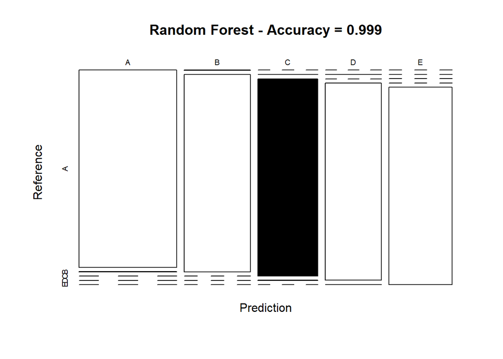

```r
# plot matrix results
plot(confMatRandForest$table, col = confMatRandForest$byClass,
     main = paste("Random Forest - Accuracy =",
                  round(confMatRandForest$overall['Accuracy'], 3)))
```

# Decision Tree

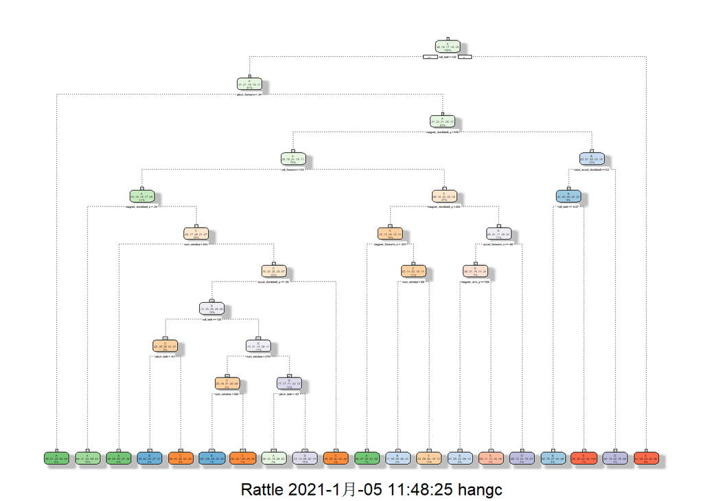

```r
# model fit
set.seed(12345)
modFitDecTree <- rpart(classe ~ ., data=TrainSet, method="class")
fancyRpartPlot(modFitDecTree)
```

```r
# prediction on Test dataset
predictDecTree <- predict(modFitDecTree, newdata=TestSet, type="class")
confMatDecTree <- confusionMatrix(predictDecTree, as.factor(TestSet$classe))
confMatDecTree
```

```
## Confusion Matrix and Statistics
##
##           Reference
## Prediction    A    B    C    D    E
##          A 1250  224   35   91   58
##          B   37  526   58   29   81
##          C   15   60  698  116   64
##          D   64  112   48  534  109
##          E   29   27   16   34  589
##
## Overall Statistics
##
##                Accuracy : 0.7335
##                  95% CI : (0.7209, 0.7458)
##     No Information Rate : 0.2845
##     P-Value [Acc > NIR] : < 2.2e-16
##
##                   Kappa : 0.661
##
##  Mcnemar's Test P-Value : < 2.2e-16
##
## Statistics by Class:
##
##                      Class: A Class: B Class: C Class: D Class: E
## Sensitivity            0.8961   0.5543   0.8164   0.6642   0.6537
## Specificity            0.8837   0.9482   0.9370   0.9188   0.9735
## Pos Pred Value         0.7539   0.7196   0.7324   0.6159   0.8475
## Neg Pred Value         0.9553   0.8986   0.9603   0.9331   0.9259
## Prevalence             0.2845   0.1935   0.1743   0.1639   0.1837
## Detection Rate         0.2549   0.1073   0.1423   0.1089   0.1201
## Detection Prevalence   0.3381   0.1491   0.1943   0.1768   0.1417
## Balanced Accuracy      0.8899   0.7512   0.8767   0.7915   0.8136
```

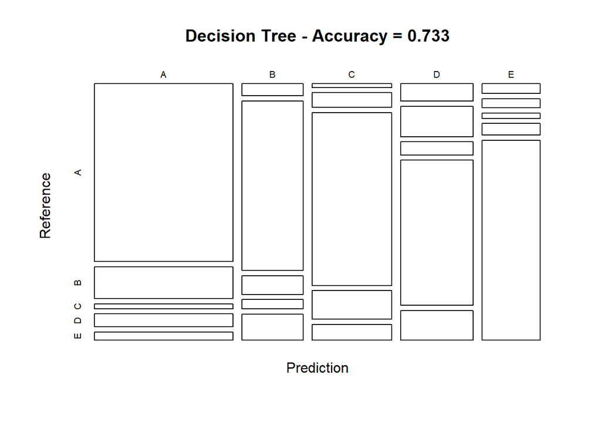

```r
# plot matrix results
plot(confMatDecTree$table, col = confMatDecTree$byClass,
     main = paste("Decision Tree - Accuracy =",
                  round(confMatDecTree$overall['Accuracy'], 3)))
```

# Generalized Boosted Model

```r
# model fit
set.seed(12345)
controlGBM <- trainControl(method = "repeatedcv", number = 5, repeats = 1)
modFitGBM  <- train(classe ~ ., data=TrainSet, method = "gbm",
                    trControl = controlGBM, verbose = FALSE)
modFitGBM$finalModel
```

```
## A gradient boosted model with multinomial loss function.
## 150 iterations were performed.
## There were 53 predictors of which 53 had non-zero influence.
```

```r
# prediction on Test dataset
predictGBM <- predict(modFitGBM, newdata=TestSet)
confMatGBM <- confusionMatrix(predictGBM, as.factor(TestSet$classe))
confMatGBM
```

```
## Confusion Matrix and Statistics
##
##           Reference
## Prediction    A    B    C    D    E
##          A 1388   14    0    0    0
##          B    6  925    6    1    3
##          C    0    9  849    8    0
##          D    1    1    0  793    9
##          E    0    0    0    2  889
##
## Overall Statistics
##
##                Accuracy : 0.9878
##                  95% CI : (0.9843, 0.9907)
##     No Information Rate : 0.2845
##     P-Value [Acc > NIR] : < 2.2e-16
##
##                   Kappa : 0.9845
##
##  Mcnemar's Test P-Value : NA
##
## Statistics by Class:
##
##                      Class: A Class: B Class: C Class: D Class: E
## Sensitivity            0.9950   0.9747   0.9930   0.9863   0.9867
## Specificity            0.9960   0.9960   0.9958   0.9973   0.9995
## Pos Pred Value         0.9900   0.9830   0.9804   0.9863   0.9978
## Neg Pred Value         0.9980   0.9939   0.9985   0.9973   0.9970
## Prevalence             0.2845   0.1935   0.1743   0.1639   0.1837
## Detection Rate         0.2830   0.1886   0.1731   0.1617   0.1813
## Detection Prevalence   0.2859   0.1919   0.1766   0.1639   0.1817
## Balanced Accuracy      0.9955   0.9853   0.9944   0.9918   0.9931
```

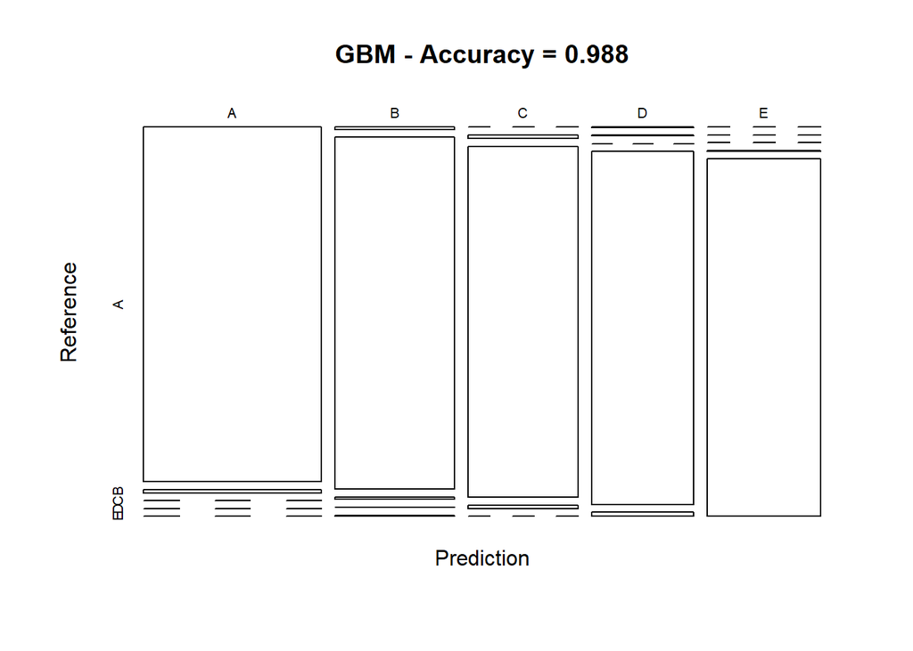

```r
# plot matrix results
plot(confMatGBM$table, col = confMatGBM$byClass,
     main = paste("GBM - Accuracy =", round(confMatGBM$overall['Accuracy'], 3)))
```

The accuracy of the three regression modeling methods above are:

Random Forest > GBM > Decision Tree

In that case, the Random Forest model will be applied to predict the test dataset as shown below.

```r
predictTest <- predict(modFitRandForest, newdata=testing)
predictTest
```

```
##  [1] B A B A A E D B A A B C B A E E A B B B
## Levels: A B C D E
```